# HardwareEfficientLayerCircuits

## Hardware Efficient Layered Circuits

In this note book I'll provide a function that created hardware efficient layered circuits like the ones in Phys. Rev. A 104, 022609 (2021). In additon I put some examples on how to both get counts from an IBM backend (you're mileage may vary on this part depending on what machines you have access to) and how to use the built in simulator to generate the ideal frequencies of the output bitstrings.

```python
#just some standard imports

import numpy as np
import scipy as sp
import scipy.linalg as la
import matplotlib.pyplot as plt
import copy

from qiskit import QuantumCircuit
import qiskit.quantum_info as qi

from qiskit import Aer, transpile
from qiskit_ibm_provider import IBMProvider

from qiskit.compiler import transpile
from qiskit.visualization import plot_gate_map
from qiskit.tools.monitor import job_monitor

from qiskit.quantum_info.random import random_unitary
from qiskit.quantum_info.synthesis import OneQubitEulerDecomposer
```

```python
#importing a backend (you will probably bne using a different provider with different accessible backends)
provider = IBMProvider(instance="ibm-q-internal/performance/benchmark")
provider.backends()
```

```
[<IBMBackend('ibm_peekskill')>,
 <IBMBackend('ibm_ithaca')>,
 <IBMBackend('ibm_sherbrooke')>]
```

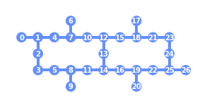

```python
backend_string='ibm_peekskill'
backend = provider.get_backend(backend_string)
coupling_map = backend.configuration().coupling_map
n_qubits = backend.configuration().n_qubits
plot_gate_map(backend)
```

### HE Layered Circuits

I'll assume we pick a set of qubits on a line somewhere, and alternate between patterns of cnots like (0,1)(2,3)... and (1,2)(3,4)... If we want to do this on n qubits, we'll just generate a generic n qubit circuit and later transpile it to exactly the qubits on the device we're interested in

```python
def HELayeredCircuit(nqubits,nlayers):
    #we'll output two ciruits, one with and without the final round of measurements.
    #This makes the simulation step slightly easier
    circ=QuantumCircuit(nqubits,nqubits)

    #first layers of single qubits
    for q in range(nqubits):
        random_u = random_unitary(2)
        circ.append(random_u,[q],[])
    for l in range(nlayers):
        ntemp = l%2
        circ.barrier()
        while (ntemp+1)<nqubits:
            circ.cnot(ntemp,ntemp+1)
            ntemp+=2
        circ.barrier()
        for q in range(nqubits):
            random_u = random_unitary(2)
            circ.append(random_u,[q],[])

    circ_nomeas = copy.deepcopy(circ)
    for q in range(nqubits):
        circ.measure(q,q)
    return circ,circ_nomeas
```

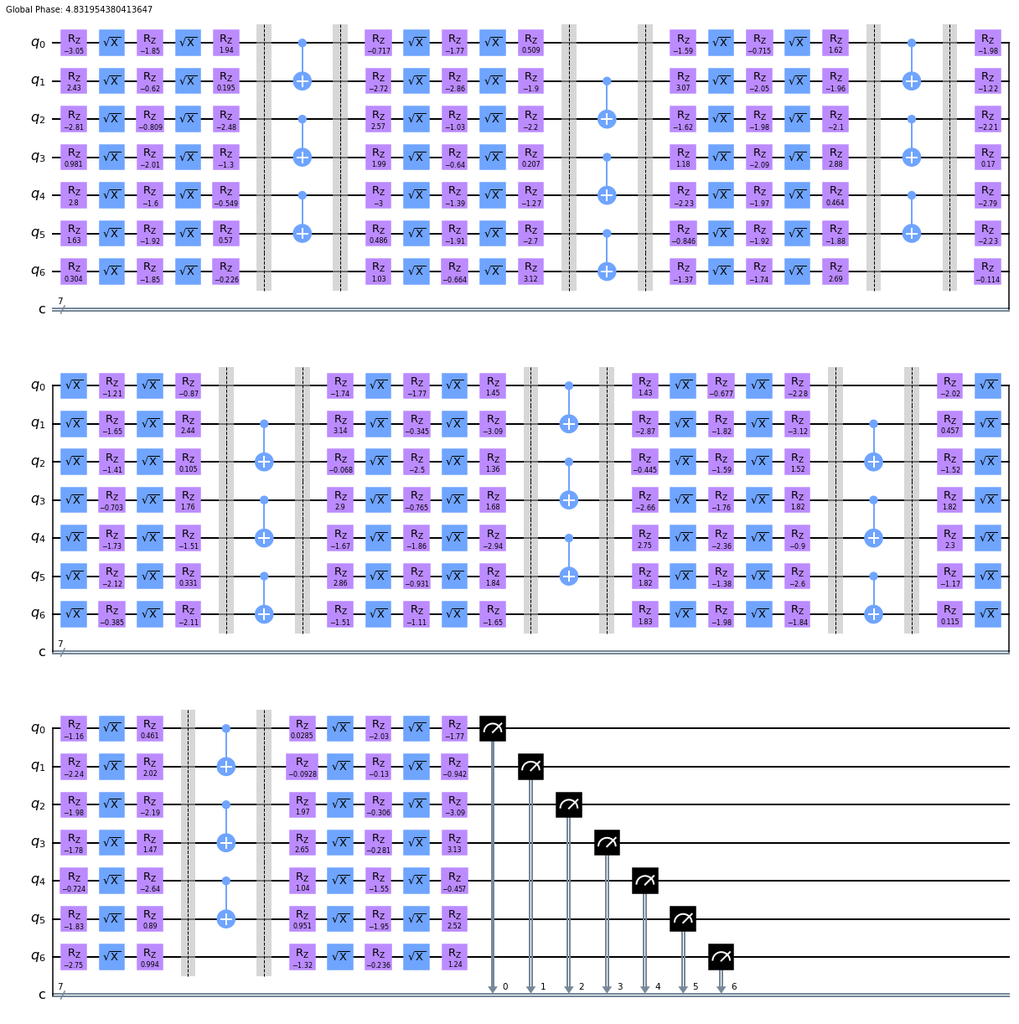

```python
'''
an example.  I choose 7 qubits just so each layer has 3 cnots.
I compiled into a particular gateset here to see that we are indeed
doing random single qubit unitaries.
'''

circ,circ_nomeas = HELayeredCircuit(7,7)
transpile(circ,basis_gates=['rz','sx','cx']).draw(output='mpl')
```

## Run on Hardware

Here's some code to run on hardware and grab some counts. Each job on my machine can run a large number of counts on about 300 unique circuits.

For my 7 qubits I'll pick the line [17,18,21,23,24,25,26]

```python
ncircs = 50
shots = 10000
qubits = [17,18,21,23,24,25,26]
all_circs=[]
all_circsnomeas=[]
for i in range(ncircs):
    circ,circ_nomeas = HELayeredCircuit(7,7)
    all_circs.append(circ)
    all_circsnomeas.append(circ_nomeas)
backend_circs = transpile(all_circs,backend,initial_layout = qubits)

job = backend.run(backend_circs,shots=shots)
print(job.job_id())
job_monitor(job)
```

```
cgrch8k5firv71231d00
Job Status: job has successfully run
```

```python
result = job.result();
def counts(circnum):
    return result.get_counts(circnum)
```

## Simulation

```python
backend_ideal = Aer.get_backend('statevector_simulator')
job_ideal = backend_ideal.run(all_circsnomeas)
job_monitor(job_ideal)
```

```
Job Status: job has successfully run
```

```python
def probs(circnum):
    return np.abs(job_ideal.result().data(circnum)['statevector'].data)**2
```

## Joining together

```python
for circnum in range(ncircs):

    output=np.zeros(2**len(qubits))
    for key in counts(circnum).keys():
        output[int(key[:],2)]+=counts(circnum)[key]
    p2 = output/np.sum(output)


    print('Circuit number {}'.format(circnum))
    print('Variational distance from exp')
    print(np.sum(np.abs(probs(circnum) - p2))/2)
    print('Variational distance from maximally mixed state')
    print(np.sum(np.abs(probs(circnum) - 1/2**len(qubits)))/2)
    print('Linear cross entropy of exp')
    print(2**len(qubits)*np.dot(p2,probs(circnum)) - 1)
```

```
Circuit number 0
Variational distance from exp
0.1951987118933013
Variational distance from maximally mixed state
0.4984115452440699
Linear cross entropy of exp
1.5920299946149936
Circuit number 1
Variational distance from exp
0.12429609418622031
Variational distance from maximally mixed state
0.35679853801789163
Linear cross entropy of exp
0.6058432308527009
Circuit number 2
Variational distance from exp
0.13284209683345038
Variational distance from maximally mixed state
0.4373616842042005
Linear cross entropy of exp
1.855393684882702
Circuit number 3
Variational distance from exp
0.13875222858041347
Variational distance from maximally mixed state
0.398022063310985
Linear cross entropy of exp
0.8040696292269824
Circuit number 4
Variational distance from exp
0.1675906727955735
Variational distance from maximally mixed state
0.3873334034025922
Linear cross entropy of exp
0.8636885663766798
Circuit number 5
Variational distance from exp
0.17087865570507368
Variational distance from maximally mixed state
0.458558253927917
```

[output cut: 295 more lines]

```
1.0485279752586907
Circuit number 48
Variational distance from exp
0.14805888438079412
Variational distance from maximally mixed state
0.3685971551926717
Linear cross entropy of exp
0.8813840799607742
Circuit number 49
Variational distance from exp
0.1549857639607943
Variational distance from maximally mixed state
0.4292341475341744
Linear cross entropy of exp
1.2958832185919853
```